# Pstat 126-HW1

# Question One

To find the Argmin of the function, first we must take the first derivative as shown in class notes. First with respect to X and then to y

w.r.t. x

$$\frac{d}{dx} (x^2+y^2-xy)\\
(\frac{d}{dx}(x^2)+\frac{d}{dx}(y^2)+\frac{d}{dx}(xy))\\
2x+0+y=2x+y\\
2x+y$$
To find the argmin, set the equations equal to 0

$$2x+y=0\\
-2x=y$$
Now we also to the same w.r.t. y

$$\frac{d}{dy} (x^2+y^2-xy)\\
(\frac{d}{dy}(x^2)+\frac{d}{dy}(y^2)+\frac{d}{dy}(xy))\\
0+2y+x\\$$

Setting the equation equal to 0

$$2y+x=0\\
-2y=x$$
we thus have the following equations.

$$\frac{d}{dx}f(x,y)=2x+y\\
\frac{d}{dy}f(x,y)=2y+x$$
solving them both at zero results in

$$2x=-y \implies y=-2x\\
2y=-x
\\then\\
2(-2x)=-x \implies 4x=x \implies x=0 \\$$

We then plug in the x

$$2y=-x \implies 2y=0 \implies y=0$$

meaning out critical points are at (0,0)

Taking the second derivatives
$$\frac{d^2}{dx^2}f(x,y)=2\\
\frac{d^2}{dy^2}f(x,y)=2$$

By the second partials test if the second derivative of the function is positive, then it is a minimum value.

# Question Two

To find $Cov(\hat{\beta}_0, \hat{\beta}_1)$

Recall that $\hat{\beta}_0$ is defined as $\bar{y} - \hat{\beta}_1 \bar{x}$

and so we get

$$Cov(\hat{\beta}_0, \hat{\beta}_1) = Cov(\bar{y} - \hat{\beta}_1 \bar{x}, \hat{\beta}_1)$$

which gets us

$$Cov(\bar{y},\hat{\beta_1})-Cov(\hat{\beta}_1\bar{x},\hat{\beta_1})
\\
Cov(\bar{y},\hat{\beta_1})-\bar{x}Cov(\hat{\beta_1},\hat{\beta_1})\\
Cov(\bar{y}, \hat{\beta_1})-\bar{x}\mathbb{V}(\hat{\beta_1})$$

We know the variance of $\hat{\beta_1}$ to be

$$\mathbb{V}(\hat{\beta_1})= \frac{\hat{\sigma}^2}{S_{xx}}$$

giving us

$$Cov(\bar{y}, \hat{\beta_1})-\bar{x}\frac{\hat{\sigma}^2}{S_{xx}}$$

$$\begin{align} \operatorname{Cov}(\bar y,\hat{\beta_1})&=\operatorname{Cov}\left(\frac{1}{n}\sum_{i=1}^n y_i,\sum_{i=1}^nc_iy_i\right)\\
&= \frac{1}{n}\sum_{i=1}^nc_i\operatorname{Var}(y_i) \\
&= \frac{\sigma^2}{n}\sum_{i=1}^nc_i=0 \end{align}$$

hence, our final result becomes

$$\begin{align}
Cov(\hat{\beta}_0, \hat{\beta}_1)=Cov(\bar{y}, \hat{\beta_1})-\bar{x}\frac{\hat{\sigma}^2}{S_{xx}}\\
&= 0-\bar{x}\frac{\hat{\sigma}^2}{S_{xx}}\\
&=-\bar{x}\frac{\hat{\sigma}^2}{S_{xx}}
\end{align}$$

# Question Three

We are to show that
$$Cov(\bar{y}, \hat{\beta}_1 (x_0 - \bar{x})) = 0$$

and so we rewrite our equation also knowing that

$$c_i=(\frac{x_o-\bar{x}}{S_{xx}}) \implies c_iS_{xx}=(x_0-\bar{x})$$

$$Cov(\frac{1}{n}\sum y, \sum c_i y_i(x_0-\bar{x}))\\
Cov(\frac{1}{n}\sum y, \sum c_i^2 y_i S_{xx})\\$$
Using bilinearity

$$\frac{1}{n} \sum c_i^2 S_{xx} \mathbb{V}(y_i)\\
\frac{\sigma^2S_{xx}}{n} \sum c_i^2$$

we know that $\sum C_i = 0$ which then gives us our result.

# Question Four

Time to create a matrix for

=
$$\begin{bmatrix}
2&2&1\\
2&5&2\\
1&2&2
\end{bmatrix}$$

```r
#creating the matrix
A <- matrix(
  data =c(2,2,1,2,5,2,1,2,2),
  nrow = 3)
A
```

```
##      [,1] [,2] [,3]
## [1,]    2    2    1
## [2,]    2    5    2
## [3,]    1    2    2
```

```r
#grabbing the eigen-vectors/values
spec_decomp = eigen(A)
#creation of P
P = spec_decomp$vectors
#inverse of P
solve(P)
```

```
##               [,1]       [,2]       [,3]
## [1,]  4.082483e-01  0.8164966  0.4082483
## [2,] -2.266233e-17 -0.4472136  0.8944272
## [3,]  9.128709e-01 -0.3651484 -0.1825742
```

```r
#transposition of P
t(P)
```

```
##           [,1]       [,2]       [,3]
## [1,] 0.4082483  0.8164966  0.4082483
## [2,] 0.0000000 -0.4472136  0.8944272
## [3,] 0.9128709 -0.3651484 -0.1825742
```

to know whether or not something is positive definite, then all the eigen-values must be positive

```r
A <- matrix(
  data =c(2,2,1,2,5,2,1,2,2),
  nrow = 3)

eigen(A)
```

```
## eigen() decomposition
## $values
## [1] 7 1 1
##
## $vectors
##           [,1]       [,2]       [,3]
## [1,] 0.4082483  0.0000000  0.9128709
## [2,] 0.8164966 -0.4472136 -0.3651484
## [3,] 0.4082483  0.8944272 -0.1825742
```

We see that the eigen values are positive and thus is positive definite.

# Question Five

```r
#grabbing our data
#install.packages("alr4")
library(alr4)
library(ggplot2)
data(UN11)
head(UN11)
```

```
##                 region  group fertility   ppgdp lifeExpF pctUrban
## Afghanistan       Asia  other     5.968   499.0    49.49       23
## Albania         Europe  other     1.525  3677.2    80.40       53
## Algeria         Africa africa     2.142  4473.0    75.00       67
## Angola          Africa africa     5.135  4321.9    53.17       59
## Anguilla     Caribbean  other     2.000 13750.1    81.10      100
## Argentina   Latin Amer  other     2.172  9162.1    79.89       93
```

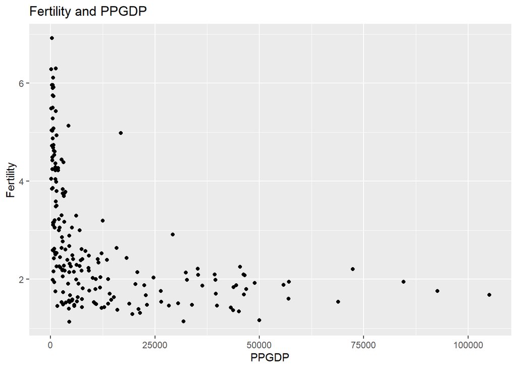

```r
ggplot(data=UN11, aes(y=fertility, x=ppgdp))+
  geom_point()+
  xlab("PPGDP")+
  ylab("Fertility")+
  ggtitle("Fertility and PPGDP")
```

As we can see, the data does not intuitively demonstrate a straight line to be the summary of the graph.

we show this by adding lines to the graph

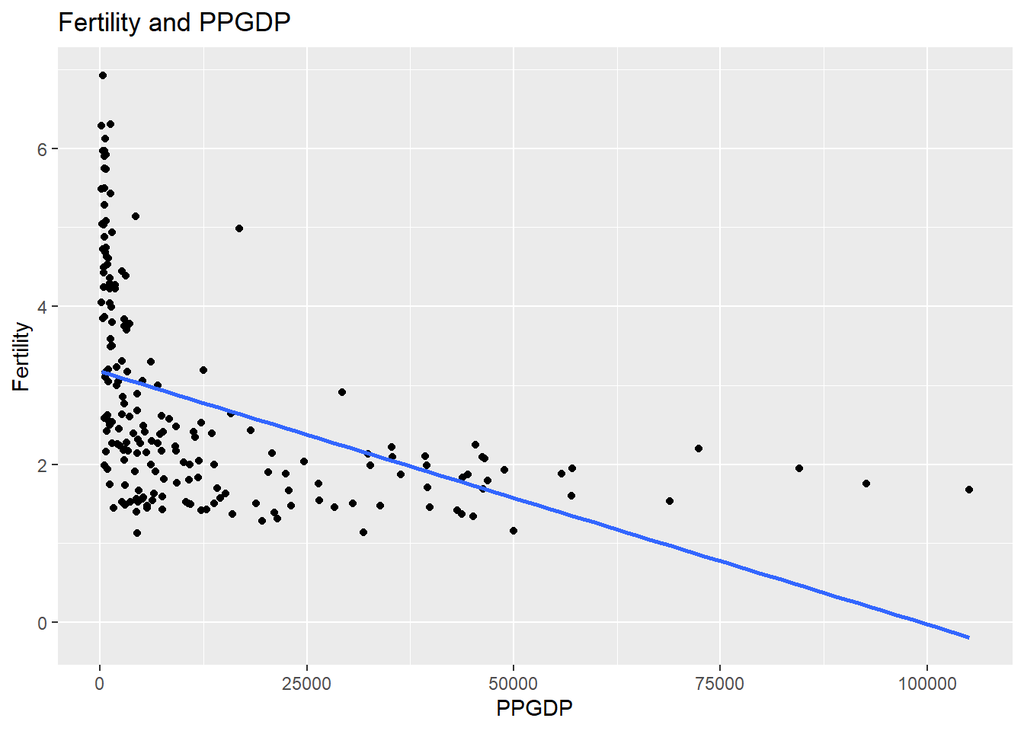

```r
ggplot(data=UN11, aes(y=fertility, x=ppgdp))+
  geom_point()+
  xlab("PPGDP")+
  ylab("Fertility")+
  ggtitle("Fertility and PPGDP")+
  geom_smooth(method=lm, se=F)
```

Seeing this as unreasonable, we ought log our data to make analysis easier.

```r
#adding the logged data to the dataframe

UN11$lnppgdp<- with(UN11, log(ppgdp))
UN11$lnfertility <- with(UN11, log(fertility))
head(UN11)
```

```
##                 region  group fertility   ppgdp lifeExpF pctUrban  lnppgdp
## Afghanistan       Asia  other     5.968   499.0    49.49       23 6.212606
## Albania         Europe  other     1.525  3677.2    80.40       53 8.209907
## Algeria         Africa africa     2.142  4473.0    75.00       67 8.405815
## Angola          Africa africa     5.135  4321.9    53.17       59 8.371450
## Anguilla     Caribbean  other     2.000 13750.1    81.10      100 9.528801
## Argentina   Latin Amer  other     2.172  9162.1    79.89       93 9.122831
##             lnfertility
## Afghanistan   1.7864119
## Albania       0.4219944
## Algeria       0.7617400
## Angola        1.6360798
## Anguilla      0.6931472
## Argentina     0.7756484
```

Now we add make our new graph

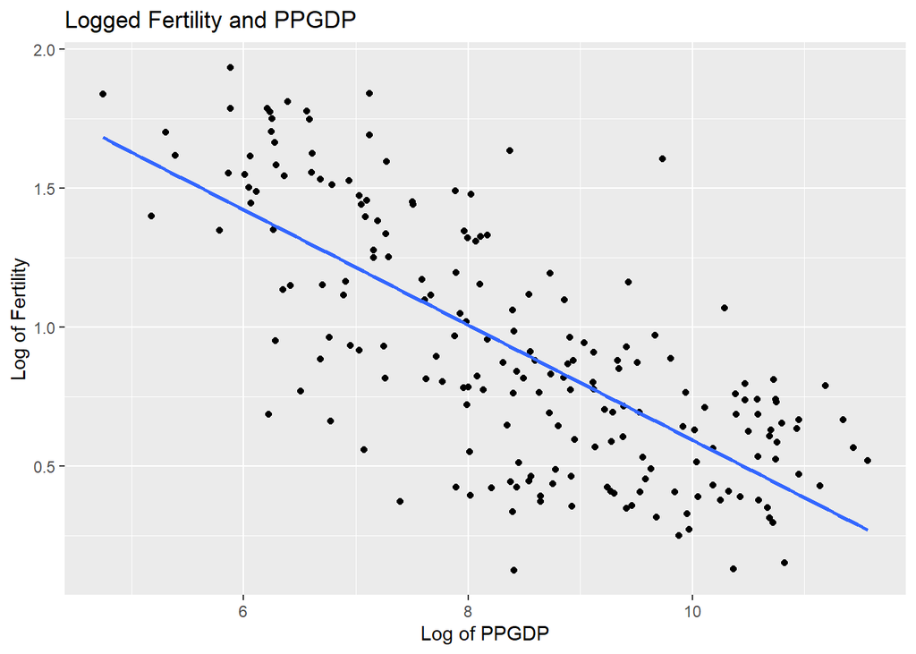

```r
UN11$lnppgdp<- with(UN11, log(ppgdp))
UN11$lnfertility <- with(UN11, log(fertility))
ggplot(data=UN11, aes(y=lnfertility, x=lnppgdp))+
  geom_point()+
  xlab("Log of PPGDP")+
  ylab("Log of Fertility")+
  ggtitle("Logged Fertility and PPGDP")+
  geom_smooth(method=lm, se=F)
```

Using a simple linear regression we get the get the following results

```r
lmod<- lm(formula = ppgdp~fertility, data=UN11)
summary(lmod)
```

```
##
## Call:
## lm(formula = ppgdp ~ fertility, data = UN11)
##
## Residuals:
##    Min     1Q Median     3Q    Max
## -19317 -10197  -4261   4237  85562
##
## Coefficients:
##             Estimate Std. Error t value Pr(>|t|)
## (Intercept)  29711.6     2697.7  11.014  < 2e-16 ***
## fertility    -6047.6      879.4  -6.877  7.9e-11 ***
## ---
## Signif. codes:  0 '***' 0.001 '**' 0.01 '*' 0.05 '.' 0.1 ' ' 1
##
## Residual standard error: 16580 on 197 degrees of freedom
## Multiple R-squared:  0.1936, Adjusted R-squared:  0.1895
## F-statistic: 47.29 on 1 and 197 DF,  p-value: 7.903e-11
```

Our model now becomes

$$H_0: \hat{\beta_1} \ge 0 \\
H_a: \hat{\beta_1} < 0$$

```r
#new_data<-data.frame(ppgdp=1000)
#names(new_data)<-c('ppgdp, xi(fertility)')
#predict(lnfertility,
  #      newdata=new_data,
  #      interval='confidence',
   #     level=c(0.95))
```